# Apontamentos dos coordenadores

Visual Strategy

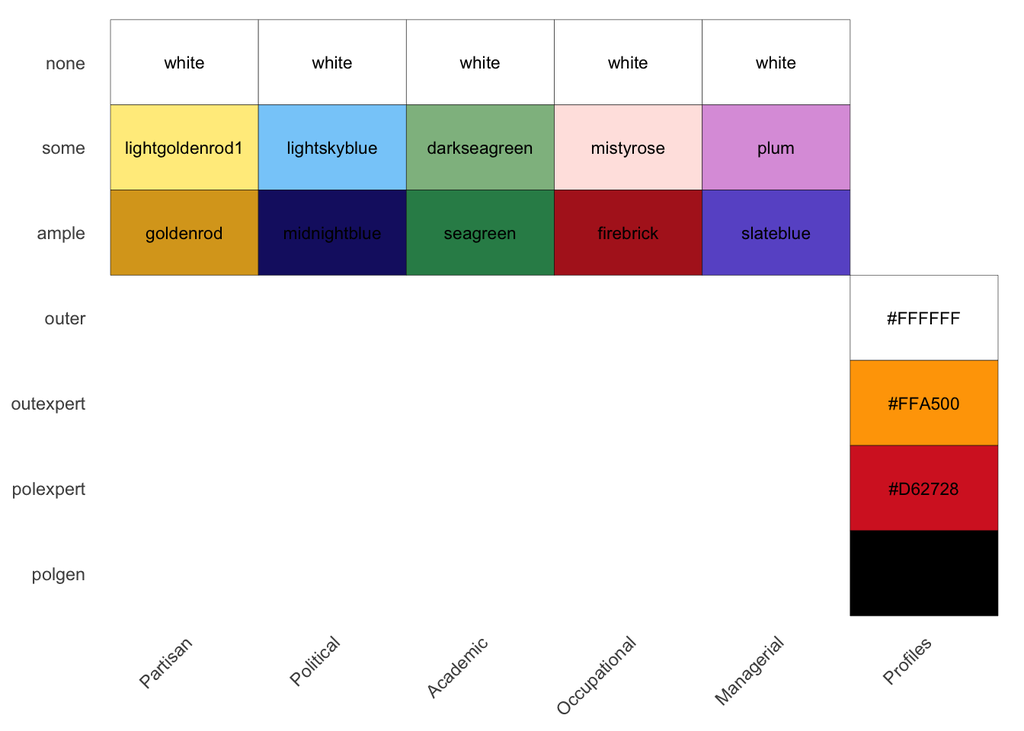

# FRAME

See here

# PORTUGAL

## ATRIBUTOS (Full period - without PM)

### Partidário

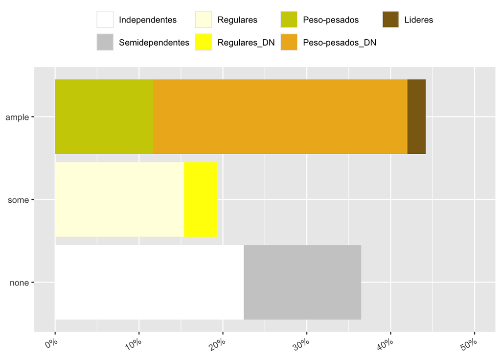

```
                 At.PARTIDÁRIO
SUBTIPO           none some ample Sum
  Independentes    114    0     0 114
  Semidependentes   71    0     0  71
  Regulares          0   78     0  78
  Regulares_DN       0   20     0  20
  Peso-pesados       0    0    59  59
  Peso-pesados_DN    0    0   154 154
  Lideres            0    0    11  11
  Sum              185   98   224 507
```

```
                 At.PARTIDÁRIO
SUBTIPO            none  some ample
  Independentes    61.6   0.0   0.0
  Semidependentes  38.4   0.0   0.0
  Regulares         0.0  79.6   0.0
  Regulares_DN      0.0  20.4   0.0
  Peso-pesados      0.0   0.0  26.3
  Peso-pesados_DN   0.0   0.0  68.8
  Lideres           0.0   0.0   4.9
  Sum             100.0 100.0 100.0
```

**Descrição Básica**

- Detectamos uma elevada presença de ministros sem filiação partidária formal: 36% do total [(114 + 71) / 507], o que está em linha com as tendências apontadas na literatura.

Contudo, os nossos dados sugerem dois elementos que atenuam essa leitura:

- Entre os ministros não filiados, 38,4% são “semi-independentes”, ou seja, ministros sem filiação formal, mas com vínculos partidários reconhecíveis a um partido específico.
- Entre os ministros filiados (98 + 224), 69% são “peso-pesados” [224 / (98 + 224)], isto é, com posições de destaque e forte influência interna nas estruturas partidárias.

Além disso, observamos mais duas evidencias indicadoras do peso dos partidos:

- Entre os partidarios que integraram a direção nacional de um partido (174 casos), 88% pertencem ao grupo dos peso-pesados [154 / (20 + 154)].
- Em governos de coligação, é comum a presença dos líderes do segundo partido da coligação no gabinete, o que reforça o papel dos partidos tradicionais na distribuição ministerial.

**Notas preliminares para uma conclusão**

- Embora os números revelem uma abertura significativa a perfis não filiados, em linha com as tendências apontadas na literatura, essa abertura é frequentemente mediada por formas de controlo partidário.
- Os vínculos indiretos dos semi-independentes e a expressiva presença de elites partidárias no gabinete — incluindo membros da direção nacional e líderes de partidos de coligação — indicam que os partidos continuam a ser atores centrais na formação dos governos portugueses.
- Este resultado confirma o argumento de Barbieri & Vercesi (2023): essa abertura é frequentemente controlada e institucionalizada, por meio de vínculos partidários indiretos ou semiexclusivos.

### Politico

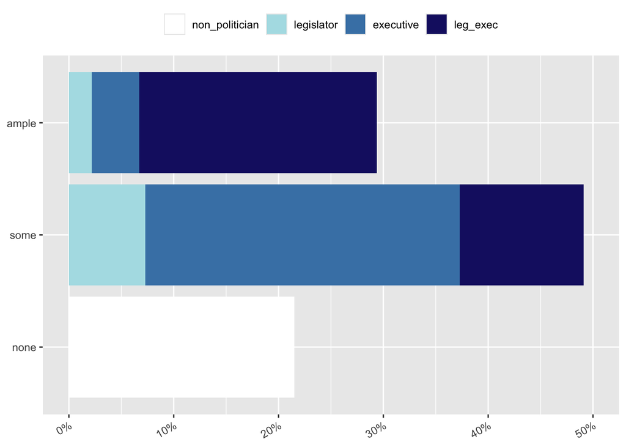

```
                At.PARTIDÁRIO
SUBTIPO          none some ample Sum
  non_politician  109    0     0 109
  legislator        0   37    11  48
  executive         0  152    23 175
  leg_exec          0   60   115 175
  Sum             109  249   149 507
```

```
                At.PARTIDÁRIO
SUBTIPO           none  some ample
  non_politician 100.0   0.0   0.0
  legislator       0.0  14.9   7.4
  executive        0.0  61.0  15.4
  leg_exec         0.0  24.1  77.2
  Sum            100.0 100.0 100.0
```

```
                At.PARTIDÁRIO
SUBTIPO           none  some ample   Sum
  non_politician 100.0   0.0   0.0 100.0
  legislator       0.0  77.1  22.9 100.0
  executive        0.0  86.9  13.1 100.0
  leg_exec         0.0  34.3  65.7 100.0
```

**Descrição Básica**

- Os nossos dados revelam um padrão claramente distinto do modelo clássico. Entre os ministros com algum grau de experiência política (“some”), predomina a experiência executiva (61%), seguida pela experiência híbrida (24%). Apenas 15% têm uma experiência exclusivamente legislativa.
- Nos níveis mais elevados de experiência (“ample”), este padrão torna-se ainda mais evidente: 77% dos ministros combinam experiência legislativa e executiva (perfil híbrido), enquanto 15% têm experiência exclusivamente executiva.
- A experiência puramente legislativa representa apenas 7% dos casos neste grupo.

**Notas preliminares para uma conclusão**

- Ao contrário do padrão descrito na literatura para regimes parlamentares, a elite ministerial portuguesa não é recrutada prioritariamente a partir da arena legislativa.
- Pelo contrário, os dados apontam para a predominância de trajectórias iniciadas na arena executiva — nomeadamente através de cargos na administração pública, governos locais e regionais, ou gabinetes ministeriais.
- Nos níveis mais elevados de experiência política (“ample”), o perfil híbrido torna-se largamente dominante, o que sugere um processo de acumulação progressiva de capital político: os ministros iniciam as suas carreiras em funções executivas e, posteriormente, complementam essa experiência com cargos legislativos ou combinam ambas as arenas.
- Este padrão revela uma forma híbrida de profissionalização política, sem que a passagem pela arena parlamentar constitua uma etapa obrigatória no acesso ao governo.